# Etude : méthodes de traitement des séries temporelles

Marlène Chevalier

12/01/2020

Executive Master Statistique et Big Data  
enseignant : Jonathan El-Methni (Paris Descartes)

# 1 Sujet : voyageurs SNCF

L’étude porte sur le nombre mensuel de voyageurs ayant emprunté le réseau SNCF entre janvier 1963 et décembre 1980. Les données sont issues du site https://freakonometrics.hypotheses.org.

Il s’agit de donner les caractéristiques de cette serie temporelle, d’en étudier la décomposition, d’en donner une modélisation en comparant différents modèles et leurs prévisions.

**Chargement des données**

```r
# chargement des données sources : matrice à 18 lignes (années) et 13 colonnes (titre année et 12 mois)
sncf=read.table("http://freakonometrics.free.fr/sncf.csv",header=TRUE,sep=";")
# conversion des données en matrice 2 colonnes : indice et nombre de passagers
sncf_vec=as.vector(t(as.matrix(sncf[,2:13])))
# conversion des données en série temporelle
d=ts(sncf_vec,start = c(1963, 1), frequency = 12)
```

# 2 Etude de la série

## 2.1 Etude graphique : tendance et saisonnalité

**Graphiques de tendance et saisonnalité : plot et monthplot**

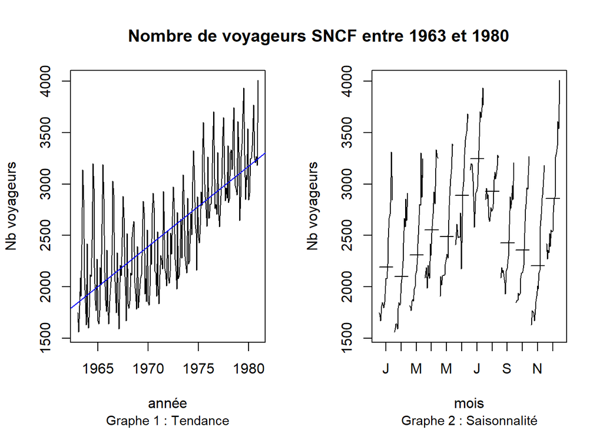

Entre 1963 et 1968, la tendance moyenne du nombre de voyageurs SNCF semble stable, puis à partir de 1968, croit régulièrement jusqu’à la fin de la période.

Une saisonnalité forte est constatée entre juin et août et en décembre (correspondant à une plus forte fréquentation du réseau SCNF pendant les vacances d’été et de Noël)

**Graphique retardé : lagplot**

Ce graphique permet de constater la correlation de la série avec elle même, à des plages de temps différentes (introduction d’un retard=lag).

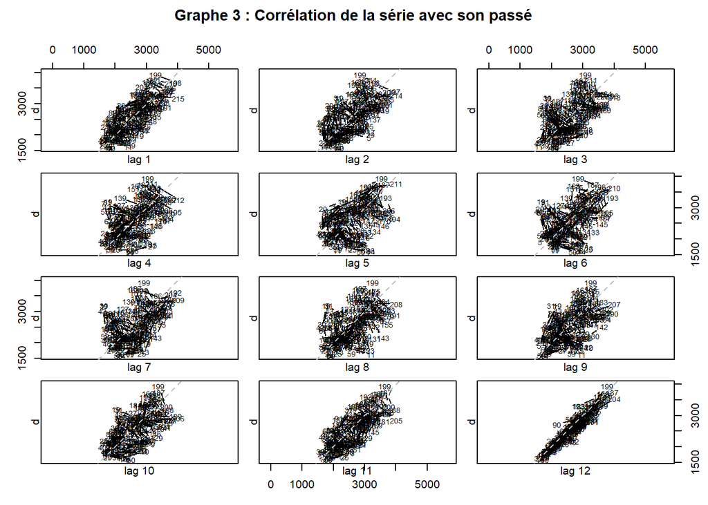

D’après le diagramme retardé, on constate une autocorrélation de la série d’ordre 12 (les points se rassemblent autour de la 1ère bissectrice pour lag12). Le nombre de voyageurs SNCF présente donc une saisonnalité annuelle.

## 2.2 Décomposition de la série

Il s’agit de mettre en évidence les composantes de la série : tendance / saisonnalité / bruit

**Décomposition manuelle**

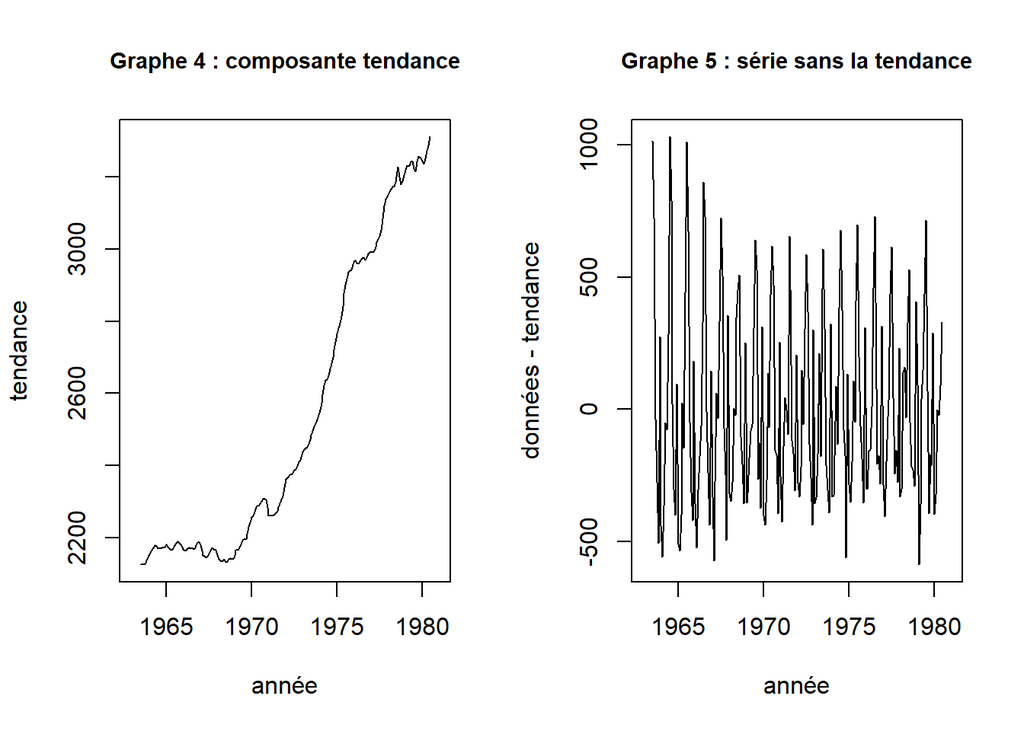

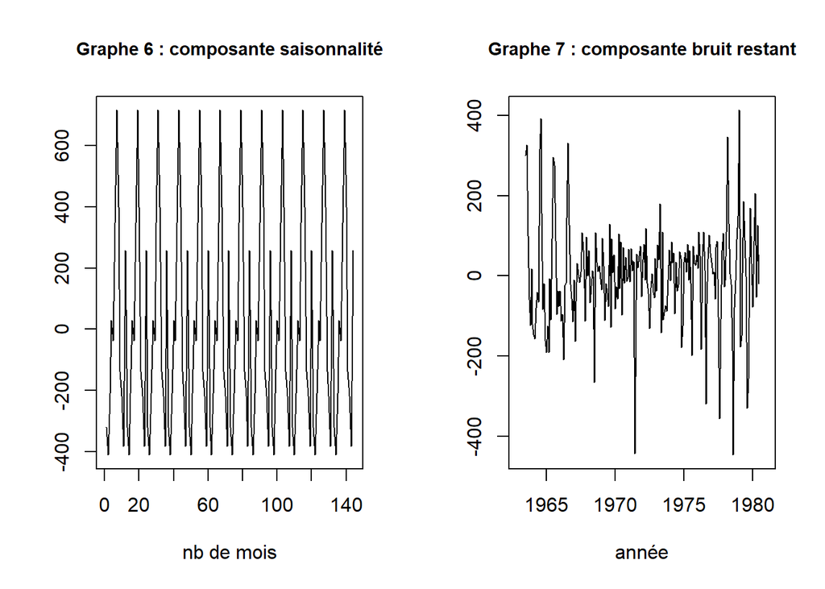

**Décomposition automatique**

On utilise ici la fonction *decompose (“additive”)* (amplitude stable de la composante saisonnière) pour obtenir l’ensemble de la décomposition.

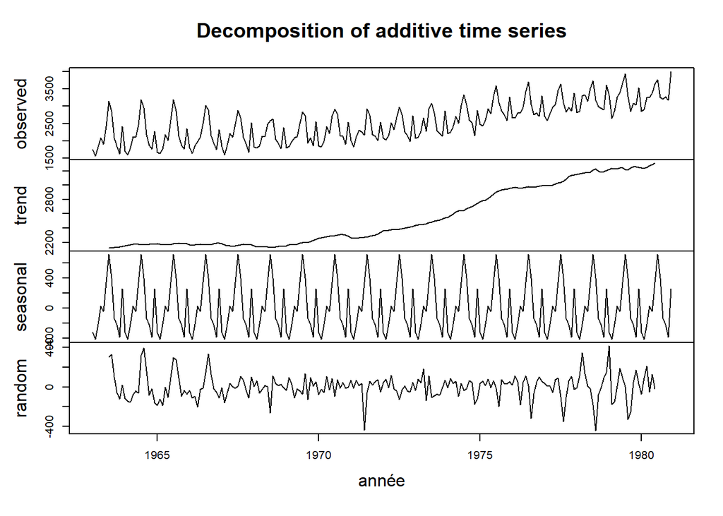

La décomposition confirme les observations graphiques de la série :

- tendance croissante (stable puis croissante à partir de 1968)
- saisonnalité d’ordre 12 et d’amplitude stable (décomposition additive de la série)

# 3 Lissage exponentiel et prévision

Il s’agit maintenant d’utiliser la méthode de lissage exponentiel pour faire une prédiction sur un an du nombre de voyageurs SNCF. Pour construire cette prédiction, nous utilisons les données de 1963 à 1979. La dernière année de données (1980) sera utilisée pour comparer la prévision calculée aux données réelles. Cela permettra d’estimer l’erreur de prediction.

Nous avons vu que la série se caractérise par une tendance croissante, une saisonnalité d’ordre 12 et une décomposition additive .Dans ce cas, on utilise d’abord le lissage exponentiel triple qui prend en compte ces caractéristiques.

## 3.1 Lissage exponentiel triple

Le lissage exponentiel triple prend en compte deux composantes additives : la tendance et la saisonnalité. Le modèle est de type “AAA”" (erreur additive aussi).

```
## ETS(A,A,A)
##
## Call:
##  ets(y = d_6379, model = "AAA")
##
##   Smoothing parameters:
##     alpha = 0.0928
##     beta  = 0.0046
##     gamma = 0.479
##
##   Initial states:
##     l = 2180.8865
##     b = 1.7331
##     s = 335.8738 -424.1515 -281.0965 -92.9194 504.7844 715.2654
##            315.7252 30.5647 20.1066 -256.943 -426.3811 -440.8287
##
##   sigma:  131.6432
##
##      AIC     AICc      BIC
## 3093.313 3096.603 3149.721
##
## Training set error measures:
##                    ME     RMSE      MAE       MPE     MAPE      MASE
## Training set 6.372573 126.3753 91.91021 0.1744532 3.681543 0.7774589
##                   ACF1
## Training set 0.2434013
```

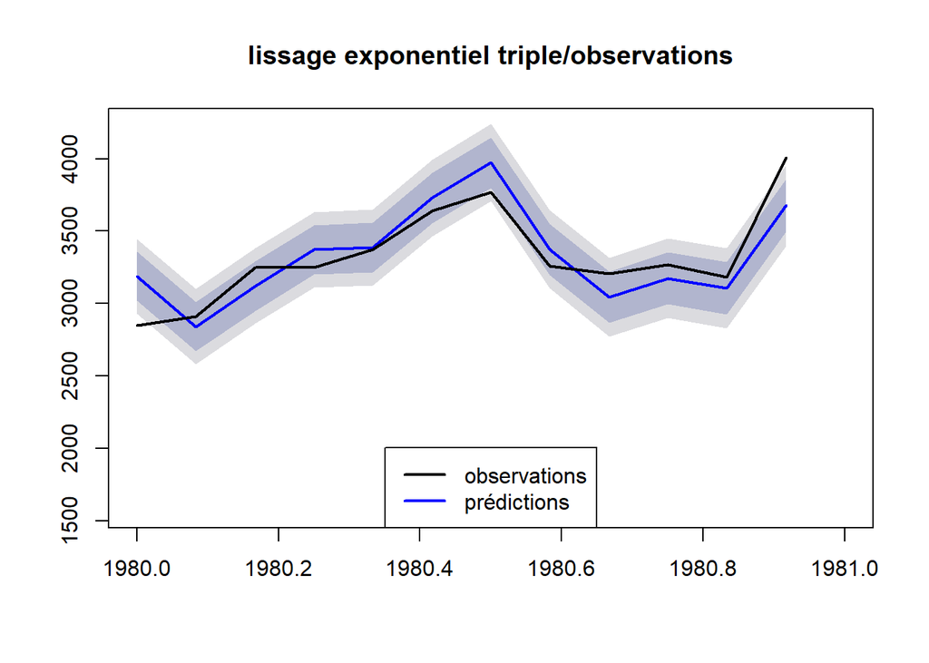

## 3.2 Lissage automatique

On sélectionne automatiquement les critères de lissage et on compare avec les prévisions du lissage exponentiel triple.

```
## ETS(M,A,M)
##
## Call:
##  ets(y = d_6379, model = "ZZZ")
##
##   Smoothing parameters:
##     alpha = 0.0933
##     beta  = 0.0072
##     gamma = 0.5124
##
##   Initial states:
##     l = 2153.812
##     b = 8.9228
##     s = 1.0998 0.7854 0.8691 0.9817 1.3335 1.453
##            1.1438 0.9331 0.987 0.85 0.7461 0.8176
##
##   sigma:  0.0496
##
##      AIC     AICc      BIC
## 3059.861 3063.152 3116.269
##
## Training set error measures:
##                     ME     RMSE      MAE       MPE     MAPE      MASE
## Training set -7.621288 125.5826 89.80574 -0.269905 3.569428 0.7596573
##                   ACF1
## Training set 0.2187159
```

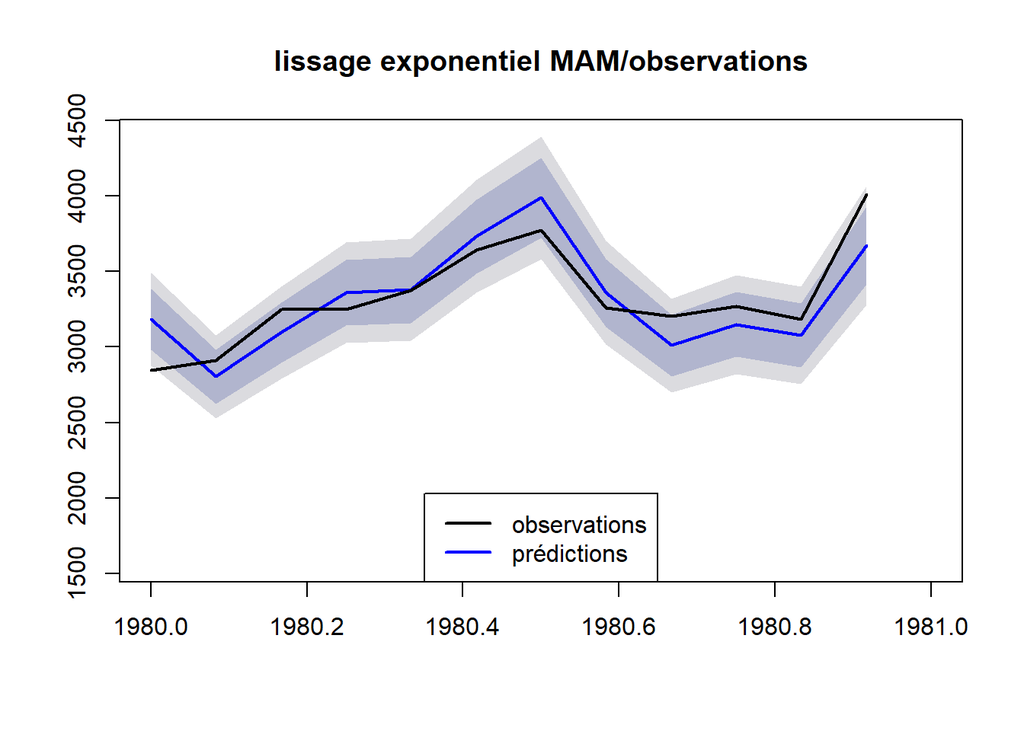

Le modèle automatique sélectionne un modèle “MAM” : erreur multiplicative, tendance additive et saisonnalité multiplicative.

**Comparaison des 2 lissages :**  
Graphiquement, il semble que les 2 prévisions soient très proches et présentent peu d’écarts avec les observations de 1980.

## 3.3 Lissage de meilleur AIC

On sélectionne le modèle de lissage donnant le meilleur AIC

```
## ETS(M,A,M)
##
## Call:
##  ets(y = d_6379, ic = "aic")
##
##   Smoothing parameters:
##     alpha = 0.0933
##     beta  = 0.0072
##     gamma = 0.5124
##
##   Initial states:
##     l = 2153.812
##     b = 8.9228
##     s = 1.0998 0.7854 0.8691 0.9817 1.3335 1.453
##            1.1438 0.9331 0.987 0.85 0.7461 0.8176
##
##   sigma:  0.0496
##
##      AIC     AICc      BIC
## 3059.861 3063.152 3116.269
##
## Training set error measures:
##                     ME     RMSE      MAE       MPE     MAPE      MASE
## Training set -7.621288 125.5826 89.80574 -0.269905 3.569428 0.7596573
##                   ACF1
## Training set 0.2187159
```

Le modèle de lissage donnant le meilleur AIC est le lissage MAM.

# 4 Processus stationnaire

Dans un premier temps, il s’agit de tester la stationnarité de la série.

## 4.1 Corrélogramme de la série : nombre de voyageurs SNCF entre 1963 et 1980

Traçons les graphiques mettant en évidence l’autocovariance et l’autocorrélation de la série. Il s’agit d’identifier le lien de la série avec son passé (même série à différents instants de retard=lag) . Si ce lien est significativement différent de 0, la série ne sera pas stationnaire. Si le corrélogramme montre une convergence vers 0, on pourra considérer que la série est stationnaire.

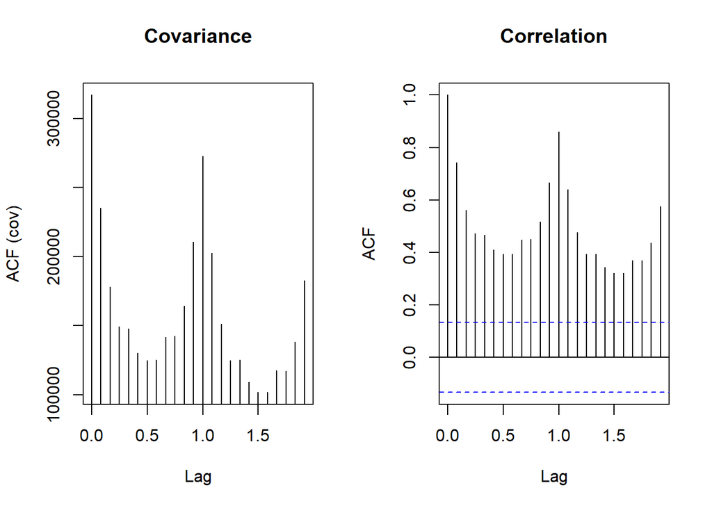

Ici la corrélation varie mais ne converge pas rapidement vers 0 (on observe une augmentation de la corrélation pour h=12 (lag= 1 an), c’est à dire une saisonnalité annuelle). La série *nombre de voyageurs SCNF* n’est donc pas stationnaire.

## 4.2 Test de blancheur

Vérifions cette observation par le test du Portemanteau (Box test) :  
H0 : les coefficients d’autocorrelation sont tous nuls jusqu’à l’ordre k (la serie est un bruit blanc, est donc stationnaire)  
H1 : il existe au moins un coefficient jusqu’à l’ordre k significativement différent de 0 (la série n’est pas un bruit blanc, on ne peut pas confirmer ou infirmer la stationnarité de la série)

```
##
##  Box-Pierce test
##
## data:  d
## X-squared = 1089.9, df = 20, p-value < 2.2e-16
```

La p_value du test est ici < 5%, par conséquent on rejette H0. La série nombre de voyageurs SNCF n’est pas un bruit blanc.

## 4.3 Se ramener à une série stationnaire

Il s’agit de ramener la série d’origine non stationnaire à une série stationnaire en utilisant l’opérateur différence : on élimine ainsi la tendance et la saisonnalité de la série. Il reste alors que la partie résiduelle de la série. On teste alors la stationnarité des résidus (corrélogramme et test du portemanteau)

**analyse du bruit restant**

```r
d_bruit=diff(diff(d,lag=12,difference=1),lag=1,difference=1)
```

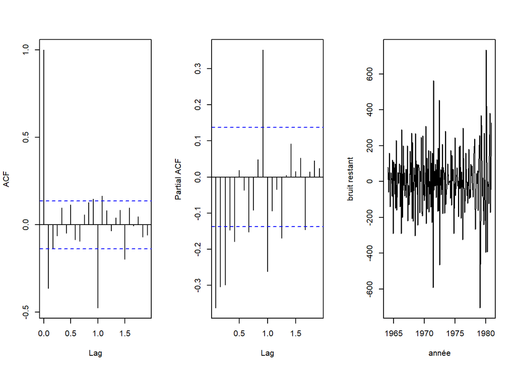

```
##
##  Box-Pierce test
##
## data:  d_bruit
## X-squared = 112.54, df = 20, p-value = 6.772e-15
```

Les résidus de la série voyageurs SNCF (série - tendance - saisonnalité) ne sont pas stationnaires.En effet, la correlation (graphe ACF) diminue mais présente des pics qui ne confirment pas la convergence vers 0 ; p-value Box Pierce<5%.

**transformation logarithmique**

Essayons de transformer la série d’origine en prenant son logarithme et regardons comment se comportent les résidus.

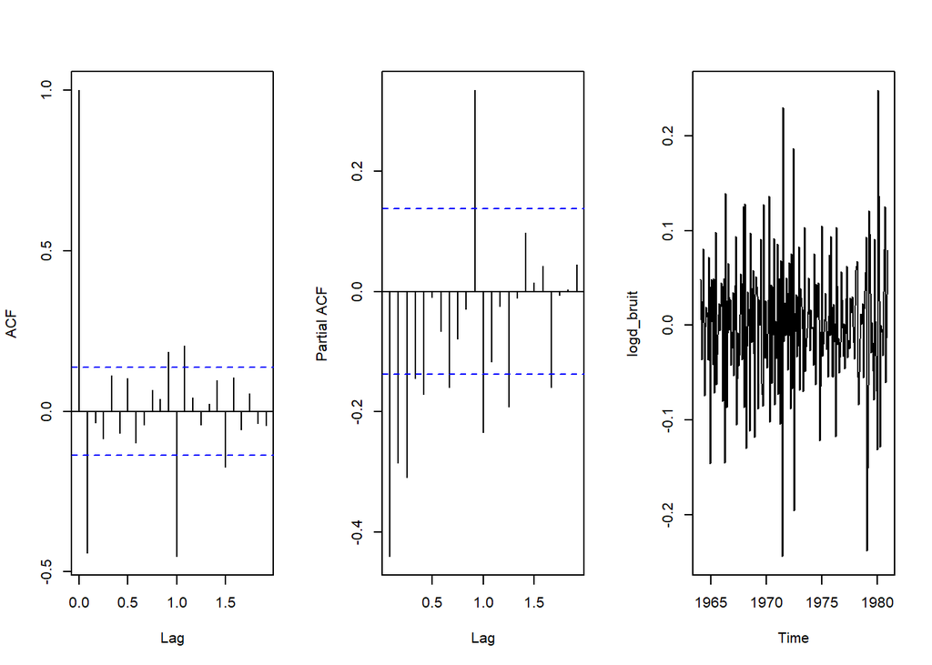

```
##
##  Box-Pierce test
##
## data:  logd_bruit
## X-squared = 118.95, df = 20, p-value = 4.441e-16
```

En prenant le logarithme de la série, les résidus n’apparaissent pas comme stationnaires.

Les tentatives de stationnarisation de la série d’origine n’ont pas abouti (test de lissage par log ou sqrt non plus). Dans l’impossibilité de stationnariser, il n’est pas possible d’utiliser les modèles de type ARMA.

# 5 Modélisation de la série et prévision

## 5.1 Sélection automatique de modèle

Voyons ce que donne la sélection automatique de modèle sur cette série : fonction auto.arima

```
##
##  Box-Pierce test
##
## data:  modelauto$residuals
## X-squared = 16.639, df = 20, p-value = 0.6762
```

Le choix de modèle automatique conclut à un modèle SARIMA (1,1,1) (0,1,1)[12]. Dans ce cas, la série des résidus est un bruit blanc (test du portemanteau >5%), elle est donc stationnaire.

## 5.2 Prévision à partir d’un modele SARIMA

La prévision pour l’année 1980 selon le modèle SARIMA choisi automatiquement donne la prediction mensuelle et 2 intervalles de prediction avec les niveaux de confiance de 80% et 95%.

```
##
## Forecast method: ARIMA(1,1,1)(0,1,1)[12]
##
## Model Information:
## Series: d_6379
## ARIMA(1,1,1)(0,1,1)[12]
##
## Coefficients:
##          ar1      ma1     sma1
##       0.2021  -0.8907  -0.4985
## s.e.  0.0828   0.0375   0.0669
##
## sigma^2 estimated as 14801:  log likelihood=-1189
## AIC=2386   AICc=2386.21   BIC=2399.01
##
## Error measures:
##                    ME     RMSE      MAE       MPE     MAPE      MASE
## Training set 5.398044 116.7929 82.36166 0.2528859 3.286532 0.6966886
##                      ACF1
## Training set 0.0004493165
##
## Forecasts:
##          Point Forecast    Lo 80    Hi 80    Lo 95    Hi 95
## Jan 1980       3176.918 3021.002 3332.833 2938.466 3415.369
## Feb 1980       2847.791 2684.491 3011.092 2598.045 3097.538
## Mar 1980       3122.217 2956.723 3287.710 2869.116 3375.317
## Apr 1980       3370.292 3203.281 3537.303 3114.871 3625.713
## May 1980       3393.392 3224.993 3561.791 3135.848 3650.936
## Jun 1980       3741.669 3571.916 3911.422 3482.054 4001.283
## Jul 1980       3986.431 3815.340 4157.523 3724.769 4248.093
## Aug 1980       3385.328 3212.908 3557.747 3121.635 3649.020
## Sep 1980       3046.176 2872.439 3219.912 2780.469 3311.882
## Oct 1980       3167.998 2992.955 3343.042 2900.293 3435.704
## Nov 1980       3102.021 2925.680 3278.361 2832.330 3371.711
## Dec 1980       3674.376 3496.747 3852.005 3402.716 3946.036
```

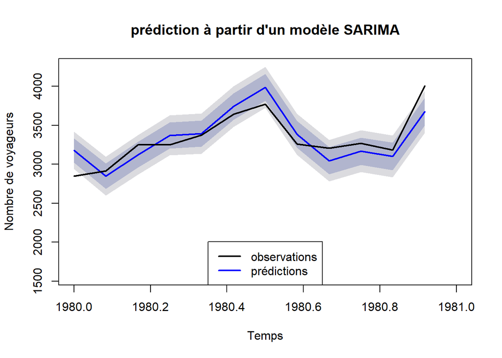

Les critères de qualité du modèle (AIC, AICc et BIC plus faibles) et de prédiction sont meilleurs avec SARIMA (1,1,1) (0,1,1)[12] (erreurs globalement plus faibles) qu’avec les modèles précédents.

## 5.3 Comparaison entre SARIMA et lissage exponentiel

**SARIMA versus lissage exponentiel triple AAA**

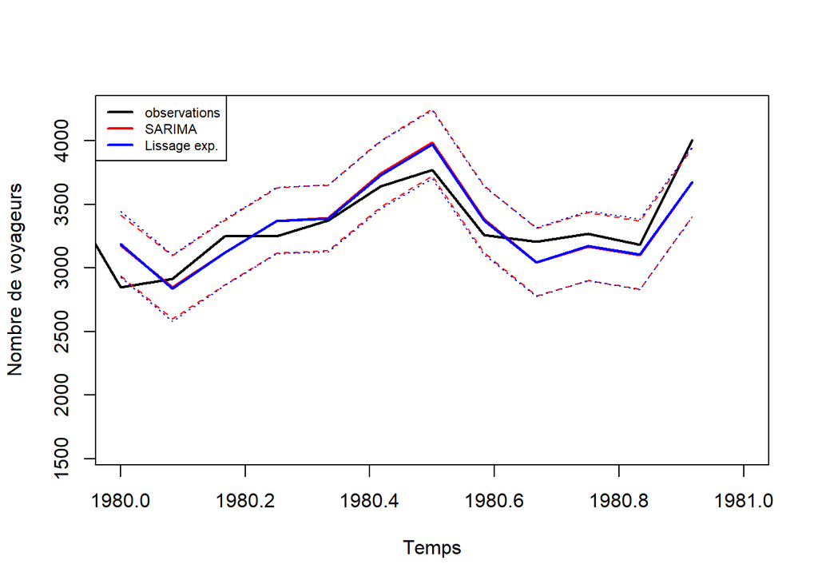

Le modèle SARIMA (1,1,1) (0,1,1)[12] est equivalent au lissage exponentiel triple. Leurs courbes de prévision et d’intervalle de prédiction sont confondues.

**SARIMA versus lissage exponentiel MAM**

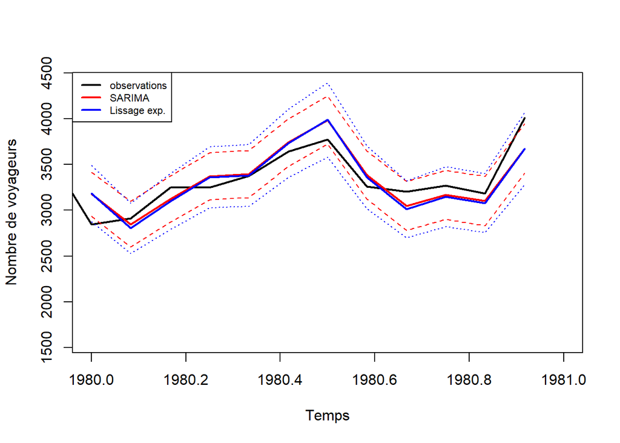

Les courbes de prévision du modèle SARIMA (1,1,1) (0,1,1)[12] et du lissage exponentiel MAM sont confondues mais l’intervalle de prediction du modèle SARIMA est plus resserré autour des observation.SARIMA (1,1,1) (0,1,1)[12] est ici meilleur.